# Feidhelm Joyce

## **4. Mapping**

```
!pip install folium
```

[output not shown]

```
colors = [
    "red", "blue", "green", "purple", "orange", "darkred", "lightred",
    "hotpink", "darkblue", "darkgreen", "cadetblue", "pink"]

districts = zurich["neighbourhood_group_cleansed"].unique()
color_map = {district: colors[i % len(colors)] for i, district in enumerate(districts)}
```

```
import folium
zurich_center = [47.3769, 8.5417]
zurich_map = folium.Map(location=zurich_center, zoom_start=12)

for _, row in zurich.iterrows():
    folium.CircleMarker(
        location=[row['latitude'], row['longitude']],
        radius=3,
        color=color_map[row['neighbourhood_group_cleansed']],
        fill=True,
        fill_opacity=0.7
    ).add_to(zurich_map)

zurich_map
```

Make this Notebook Trusted to load map: File -> Trust Notebook

[interactive chart not shown]

The geographic distribution of Airbnb rentals across Zurich shows a strong concentration of listings in and around the city center, particularly near District 1 and other walkable, transit-rich neighborhoods. This reflects visitor demand for proximity to major attractions, restaurants, and transportation hubs such as Zurich Hauptbahnhof and Bahnhofstrasse. A clear corridor of listings also extends south along Lake Zurich, indicating the appeal of scenic waterfront areas for both hosts and guests.

In contrast, more suburban and industrial zones farther from the core display much lower listing density, suggesting that Airbnb activity is highly aligned with accessibility and the desirability of urban and lakeside environments. Overall, the map highlights how tourism demand in Zurich clusters around vibrant central neighborhoods and the lakefront — areas that offer convenience, lifestyle benefits, and strong amenities for travelers.

## **5. Word Cloud**

```
!pip install wordcloud
```

[output not shown]

```
from wordcloud import WordCloud, STOPWORDS

clean_text_series = zurich["neighborhood_overview"].dropna()
clean_text_series = clean_text_series[clean_text_series.str.lower() != "Unknown"]

text = " ".join(clean_text_series)
custom_stopwords = STOPWORDS.union({"unknown", "zurich", "room", "apartment", "br"})

wc = WordCloud(
    width=1200,
    height=600,
    background_color="white",
    colormap="viridis",
    stopwords=custom_stopwords).generate(text)

plt.figure(figsize=(14,7))
plt.imshow(wc, interpolation='bilinear')
plt.axis("off")
plt.title("WordCloud of Neighborhood Overview Text (Unknown Removed)")
plt.show()
```

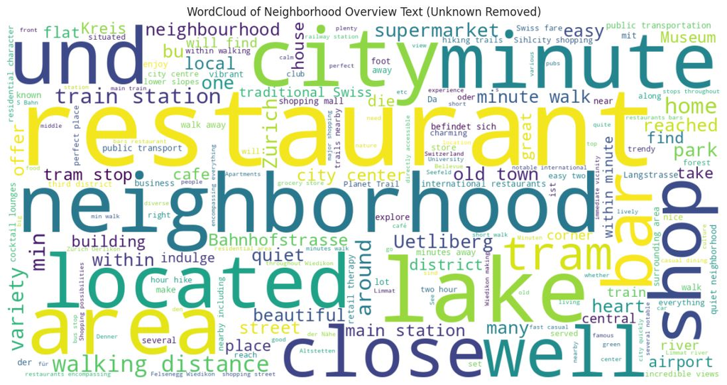

The most emphasized terms in the neighborhood descriptions highlight proximity to key amenities and walkability. Words such as “restaurant,” “city,” “shops,” “minute,” “walking,” “train station,” and “tram” appear prominently, suggesting hosts focus on convenient access to dining, transportation, and city attractions. Additional frequent terms like “lake,” “park,” “quiet,” and “central” reflect Zurich’s balance of natural beauty with an accessible, high-quality urban lifestyle. Overall, hosts consistently market location advantages, especially short travel times, local amenities, and attractive surroundings, as the main selling points of their listings.

# **Prediction**

```
zurich.head()
```

|  | id | name | description | neighborhood_overview | host_id | host_name | host_since | host_location | host_about | host_response_time | host_response_rate | host_acceptance_rate | host_is_superhost | host_neighbourhood | host_listings_count | host_total_listings_count | neighbourhood_cleansed | neighbourhood_group_cleansed | latitude | longitude | property_type | room_type | accommodates | bedrooms | beds | amenities | price | minimum_nights | maximum_nights | … |
| --- | --- | --- | --- | --- | --- | --- | --- | --- | --- | --- | --- | --- | --- | --- | --- | --- | --- | --- | --- | --- | --- | --- | --- | --- | --- | --- | --- | --- | --- | --- |
| 1 | 178448.0 | Rental unit in Zurich · ★4.89 · 1 bedroom · 1 ... | Very central location, 5 min walk from Bahnhof... | We live in one of the top locations of Zürich,... | 854016 | Delphine | 7/22/2011 | Zurich, Switzerland | I am a quiet, friendly and caring person\r\nI ... | within an hour | 100.0 | 94.5 | False | Unknown | 1 | 1 | Enge | Kreis 2 | 47.36514 | 8.52615 | Private room in rental unit | Private room | 1 | 1.0 | 1.0 | ["Hangers", "Lake access", "Shampoo", "Wifi", ... | 60.0 | 5 | 31 | … |
| 2 | 204586.0 | Rental unit in Zurich · 1 bedroom · 1 bed · 1 ... | <b>The space</b><br />share a room in a very n... |  | 1004816 | Aicha | 8/22/2011 | Zurich, Switzerland | I'm a very active person, love traveling, cook... | within an hour | 100.0 | 100.0 | False | Unknown | 1 | 1 | Höngg | Kreis 10 | 47.40644 | 8.48385 | Private room in rental unit | Private room | 1 | 1.0 | 1.0 | ["Wifi", "Dryer", "TV with standard cable", "K... | 200.0 | 3 | 6 | … |
| 3 | 222565.0 | Home in Zurich · ★4.60 · 1 bedroom · 1 bed · 1... | <b>The space</b><br />Wir bieten ein großes Zi... | In der Nähe befinde sich Lind die Chokolade Fa... | 1155866 | Ysabel | 9/14/2011 | Zurich, Switzerland | We are a multicultural family. We like arts an... | within an hour | 100.0 | 98.0 | False | Unknown | 3 | 7 | Wollishofen | Kreis 2 | 47.33438 | 8.54078 | Private room in home | Private room | 2 | 1.0 | 1.0 | ["Private entrance", "Free street parking", "T... | 79.0 | 2 | 30 | … |
| 4 | 227039.0 | Loft in Zurich · ★4.97 · 2 bedrooms · 2 beds ·... | Modern and unique penthouse apartment over thr... | Zurich is hip-circuit with the Swiss peacefuln... | 1184427 | Lucas | 9/20/2011 | Zurich, Switzerland | I'm a Swiss management consultant and enjoy tr... | within a day | 100.0 | 67.0 | False | Unknown | 2 | 2 | Escher Wyss | Kreis 5 | 47.38942 | 8.51881 | Entire loft | Entire home/apt | 3 | 2.0 | 2.0 | ["Shared sauna", "Books and reading material",... | 500.0 | 4 | 10 | … |
| 5 | 251204.0 | Rental unit in Zurich · 1 bedroom · 1 bed · 1 ... | The renovated 3 1/2 room apartment is located ... | The Wipkingen district currently enjoys the st... | 1224284 | Urban | 9/29/2011 | Zürich, Switzerland | working as a UX/UI Designer. I am reliable, li... | within an hour | 100.0 | 100.0 | False | Unknown | 1 | 4 | Wipkingen | Kreis 10 | 47.39282 | 8.52685 | Entire rental unit | Entire home/apt | 2 | 1.0 | 1.0 | ["TV", "Bed linens", "Dining table", "Hot wate... | 145.0 | 5 | 30 | … |

```
zurich.info()
```

```
<class 'pandas.core.frame.DataFrame'>
Index: 2486 entries, 1 to 2533
Data columns (total 49 columns):
 #   Column                                        Non-Null Count  Dtype
---  ------                                        --------------  -----
 0   id                                            2486 non-null   float64
 1   name                                          2486 non-null   object
 2   description                                   2486 non-null   object
 3   neighborhood_overview                         2486 non-null   object
 4   host_id                                       2486 non-null   int64
 5   host_name                                     2486 non-null   object
 6   host_since                                    2486 non-null   object
 7   host_location                                 2486 non-null   object
 8   host_about                                    2486 non-null   object
 9   host_response_time                            2486 non-null   object
 10  host_response_rate                            2486 non-null   float64
 11  host_acceptance_rate                          2486 non-null   float64
 12  host_is_superhost                             2486 non-null   bool
 13  host_neighbourhood                            2486 non-null   object
 14  host_listings_count                           2486 non-null   int64
 15  host_total_listings_count                     2486 non-null   int64
 16  neighbourhood_cleansed                        2486 non-null   object
 17  neighbourhood_group_cleansed                  2486 non-null   object
 18  latitude                                      2486 non-null   float64
 19  longitude                                     2486 non-null   float64
 20  property_type                                 2486 non-null   object
 21  room_type                                     2486 non-null   object
 22  accommodates                                  2486 non-null   int64
 23  bedrooms                                      2486 non-null   float64
 24  beds                                          2486 non-null   float64
 25  amenities                                     2486 non-null   object
 26  price                                         2486 non-null   float64
 27  minimum_nights                                2486 non-null   int64
 28  maximum_nights                                2486 non-null   int64
 29  has_availability                              2486 non-null   object
 30  availability_30                               2486 non-null   int64
 31  availability_60                               2486 non-null   int64
 32  availability_90                               2486 non-null   int64
 33  availability_365                              2486 non-null   int64
 34  number_of_reviews                             2486 non-null   int64
 35  review_scores_rating                          2486 non-null   float64
 36  review_scores_accuracy                        2486 non-null   float64
 37  review_scores_cleanliness                     2486 non-null   float64
 38  review_scores_checkin                         2486 non-null   float64
 39  review_scores_communication                   2486 non-null   float64
 40  review_scores_location                        2486 non-null   float64
 41  review_scores_value                           2486 non-null   float64
 42  instant_bookable                              2486 non-null   object
 43  calculated_host_listings_count                2486 non-null   int64
 44  calculated_host_listings_count_entire_homes   2486 non-null   int64
 45  calculated_host_listings_count_private_rooms  2486 non-null   int64
 46  calculated_host_listings_count_shared_rooms   2486 non-null   int64
 47  reviews_per_month                             2486 non-null   float64
 48  bathrooms_clean                               2486 non-null   float64
dtypes: bool(1), float64(17), int64(15), object(16)
memory usage: 954.1+ KB
```

```
seed_value = 789
np.random.seed(seed_value)
```

```
from sklearn.model_selection import train_test_split
from sklearn.preprocessing import StandardScaler
from sklearn.linear_model import LinearRegression
```

```
num_cols = [
    "beds",
    "availability_30", "availability_60", "availability_90", "availability_365",
    "host_acceptance_rate", "host_response_rate",
    "minimum_nights", "maximum_nights",
    "review_scores_rating", "review_scores_location", "review_scores_value"]

binary_cols = ["host_is_superhost", "instant_bookable", "has_availability"]

cat_cols = ["property_type", "neighbourhood_cleansed"]


X = zurich[num_cols + binary_cols + cat_cols].copy()
y = zurich["price"]
```

```
bin_map = {"t": 1, "f": 0, "True": 1, "False": 0}

for col in binary_cols:
    X[col] = X[col].astype(str).map(bin_map)
```

```
X = pd.get_dummies(X, columns=cat_cols, drop_first=True)
```

```
scaler = StandardScaler()
X[num_cols] = scaler.fit_transform(X[num_cols])
```

```
X_train, X_test, y_train, y_test = train_test_split(X, y, test_size=0.2, random_state=seed_value)
```

```
mask_train = ~X_train.isna().any(axis=1)
X_train = X_train[mask_train]
y_train = y_train[mask_train]
```

```
model = LinearRegression()
model.fit(X_train, y_train)

print("Model Coefficients:", model.coef_)
print("Model Intercept:", model.intercept_)
```

```
Model Coefficients: [ 2.81941313e+01  9.26055640e+00  2.00679077e+01 -1.91436769e+01
  2.34819708e+01  5.07123715e+00  5.10056648e+00 -1.37480778e+01
  1.38213147e+01  6.65712376e+00 -2.49063916e+00 -1.98417692e+00
 -1.84897070e+01  3.87239301e+01  7.07236499e+00  1.94218277e+02
 -5.79280806e+01  7.38235165e+01 -4.18422989e+01 -3.12795793e+01
  6.36821565e+01  5.95261256e+01  5.52914908e+01  5.70018786e+01
 -3.12039604e+01  2.18546808e+01  3.50645136e+02 -4.09745597e+01
 -1.13977452e+01 -5.10621675e+01 -1.20445780e+02  8.46165464e+01
  2.65433733e+02 -1.78318006e+01 -1.27147223e+02 -3.92335398e+01
 -1.10535191e+02 -1.79230624e+01 -2.19705784e+01 -1.88541906e+00
 -2.41662588e+01 -1.80409272e+01 -6.68583701e+01 -1.03192316e+02
  1.00905706e+02  1.13686838e-13 -2.09565552e+01 -1.11645389e+02
 -1.04196458e+02 -4.64107811e+01  3.29045209e+01  5.53944311e+01
  4.39825946e+00  8.73484321e+01  4.20605104e+02  1.70046869e+01
  4.77855688e+01  1.75748140e+01  2.11483082e+01  5.09405961e+01
 -7.66167344e+00 -2.80119134e+00  2.30474962e+01  4.93906206e+01
  2.20971978e+01 -4.78874936e+00  3.69781137e+01 -2.60623369e+01
  6.29030526e+01 -1.49119360e+00  3.87736626e+01  3.40255210e+01
  4.27809783e+01  2.60253460e+01  3.32044022e+00 -5.28292119e+00
  4.10200131e+01 -4.48985675e+00  3.22625248e+01 -3.85429709e+00
  3.09252808e+01  3.87399437e+00  9.00951381e-01  1.63785133e+01]
Model Intercept: 94.04915484565693
```

```
from sklearn.metrics import r2_score

mask_test = ~X_test.isna().any(axis=1)
X_test = X_test[mask_test]
y_test = y_test[mask_test]

y_train_pred = model.predict(X_train)
y_test_pred = model.predict(X_test)

r2_train = r2_score(y_train, y_train_pred)
r2_test = r2_score(y_test, y_test_pred)

print(f"R-squared on training data: {r2_train:.2f}")
print(f"R-squared on test data: {r2_test:.2f}")
```

```
R-squared on training data: 0.40
R-squared on test data: 0.27
```

```
X_train_fixed = X_train.copy()
X_test_fixed  = X_test.copy()

bool_cols = X_train_fixed.select_dtypes(include=["bool"]).columns

X_train_fixed[bool_cols] = X_train_fixed[bool_cols].astype(int)
X_test_fixed[bool_cols]  = X_test_fixed[bool_cols].astype(int)
```

```
import statsmodels.api as sm

X_train_const = sm.add_constant(X_train_fixed.astype(float))
ols_model = sm.OLS(y_train, X_train_const).fit()

print(ols_model.summary())
```

```
                            OLS Regression Results
==============================================================================
Dep. Variable:                  price   R-squared:                       0.401
Model:                            OLS   Adj. R-squared:                  0.375
Method:                 Least Squares   F-statistic:                     15.37
Date:                Wed, 10 Dec 2025   Prob (F-statistic):          1.60e-156
Time:                        03:22:06   Log-Likelihood:                -11959.
No. Observations:                1988   AIC:                         2.409e+04
Df Residuals:                    1904   BIC:                         2.456e+04
Df Model:                          83
Covariance Type:            nonrobust
====================================================================================================================
                                                       coef    std err          t      P>|t|      [0.025      0.975]
--------------------------------------------------------------------------------------------------------------------
const                                               94.0492    104.797      0.897      0.370    -111.479     299.577
beds                                                28.1941      2.472     11.404      0.000      23.346      33.043
availability_30                                      9.2606      6.799      1.362      0.173      -4.073      22.594
availability_60                                     20.0679     14.559      1.378      0.168      -8.486      48.622
availability_90                                    -19.1437     11.262     -1.700      0.089     -41.231       2.944
availability_365                                    23.4820      3.296      7.123      0.000      17.017      29.947
host_acceptance_rate                                 5.0712      2.837      1.787      0.074      -0.493      10.635
host_response_rate                                   5.1006      2.608      1.956      0.051      -0.014      10.215
minimum_nights                                     -13.7481      2.492     -5.517      0.000     -18.636      -8.861
maximum_nights                                      13.8213      2.482      5.568      0.000       8.953      18.689
review_scores_rating                                 6.6571      3.220      2.067      0.039       0.342      12.973
review_scores_location                              -2.4906      2.802     -0.889      0.374      -7.986       3.005
review_scores_value                                 -1.9842      3.279     -0.605      0.545      -8.415       4.447
host_is_superhost                                  -18.4897      6.192     -2.986      0.003     -30.633      -6.347
instant_bookable                                    38.7239      6.096      6.352      0.000      26.769      50.679
has_availability                                     7.0724     16.298      0.434      0.664     -24.891      39.036
property_type_Camper/RV                            194.2183    126.306      1.538      0.124     -53.494     441.930
property_type_Casa particular                      -57.9281    126.010     -0.460      0.646    -305.061     189.204
property_type_Entire condo                          73.8235    102.890      0.717      0.473    -127.965     275.612
property_type_Entire guest suite                   -41.8423    117.876     -0.355      0.723    -273.022     189.337
property_type_Entire guesthouse                    -31.2796    125.068     -0.250      0.803    -276.565     214.006
property_type_Entire home                           63.6822    104.802      0.608      0.543    -141.857     269.222
property_type_Entire loft                           59.5261    103.515      0.575      0.565    -143.488     262.540
property_type_Entire rental unit                    55.2915    102.175      0.541      0.588    -145.095     255.678
property_type_Entire serviced apartment             57.0019    102.760      0.555      0.579    -144.532     258.535
property_type_Entire townhouse                     -31.2040    118.175     -0.264      0.792    -262.971     200.563
property_type_Entire vacation home                  21.8547    144.455      0.151      0.880    -261.452     305.162
property_type_Entire villa                         350.6451    145.046      2.417      0.016      66.179     635.111
property_type_Private room                         -40.9746    125.460     -0.327      0.744    -287.028     205.079
property_type_Private room in bed and breakfast    -11.3977    106.955     -0.107      0.915    -221.160     198.364
property_type_Private room in cabin                -51.0622    144.257     -0.354      0.723    -333.980     231.856
property_type_Private room in casa particular     -120.4458    143.722     -0.838      0.402    -402.315     161.423
property_type_Private room in castle                84.6165    144.729      0.585      0.559    -199.227     368.461
property_type_Private room in chalet               265.4337    144.518      1.837      0.066     -17.997     548.864
property_type_Private room in condo                -17.8318    104.370     -0.171      0.864    -222.523     186.860
property_type_Private room in guesthouse          -127.1472    144.319     -0.881      0.378    -410.186     155.892
property_type_Private room in home                 -39.2335    103.995     -0.377      0.706    -243.190     164.723
property_type_Private room in hut                 -110.5352    144.120     -0.767      0.443    -393.184     172.114
property_type_Private room in loft                 -17.9231    107.858     -0.166      0.868    -229.456     193.610
property_type_Private room in rental unit          -21.9706    102.237     -0.215      0.830    -222.479     178.538
property_type_Private room in serviced apartment    -1.8854    112.145     -0.017      0.987    -221.825     218.054
property_type_Private room in townhouse            -24.1663    108.241     -0.223      0.823    -236.449     188.117
property_type_Private room in villa                -18.0409    106.416     -0.170      0.865    -226.745     190.663
property_type_Room in bed and breakfast            -66.8584    143.805     -0.465      0.642    -348.890     215.173
property_type_Room in boutique hotel              -103.1923    110.646     -0.933      0.351    -320.192     113.807
property_type_Room in hotel                        100.9057    103.746      0.973      0.331    -102.562     304.374
property_type_Room in serviced apartment          -8.57e-14   1.53e-13     -0.561      0.575   -3.85e-13    2.14e-13
property_type_Shared room in home                  -20.9566    144.912     -0.145      0.885    -305.160     263.247
property_type_Shared room in hostel               -111.6454    109.141     -1.023      0.306    -325.694     102.403
property_type_Shared room in hotel                -104.1965    145.591     -0.716      0.474    -389.731     181.338
property_type_Shared room in rental unit           -46.4108    108.335     -0.428      0.668    -258.878     166.056
property_type_Tiny home                             32.9045    118.553      0.278      0.781    -199.603     265.412
neighbourhood_cleansed_Albisrieden                  55.3944     23.755      2.332      0.020       8.805     101.984
neighbourhood_cleansed_Alt-Wiedikon                  4.3983     19.338      0.227      0.820     -33.528      42.325
neighbourhood_cleansed_Altstetten                   87.3484     18.811      4.644      0.000      50.457     124.240
neighbourhood_cleansed_City                        420.6051     42.330      9.936      0.000     337.586     503.624
neighbourhood_cleansed_Enge                         17.0047     20.477      0.830      0.406     -23.155      57.164
neighbourhood_cleansed_Escher Wyss                  47.7856     23.038      2.074      0.038       2.603      92.968
neighbourhood_cleansed_Fluntern                     17.5748     25.478      0.690      0.490     -32.393      67.543
neighbourhood_cleansed_Friesenberg                  21.1483     22.953      0.921      0.357     -23.867      66.164
neighbourhood_cleansed_Gewerbeschule                50.9406     20.784      2.451      0.014      10.179      91.702
neighbourhood_cleansed_Hard                         -7.6617     20.493     -0.374      0.709     -47.852      32.529
neighbourhood_cleansed_Hirslanden                   -2.8012     21.857     -0.128      0.898     -45.668      40.066
neighbourhood_cleansed_Hirzenbach                   23.0475     29.203      0.789      0.430     -34.226      80.321
neighbourhood_cleansed_Hochschulen                  49.3906     29.778      1.659      0.097      -9.010     107.792
neighbourhood_cleansed_Hottingen                    22.0972     20.802      1.062      0.288     -18.699      62.894
neighbourhood_cleansed_Höngg                        -4.7887     21.509     -0.223      0.824     -46.972      37.394
neighbourhood_cleansed_Langstrasse                  36.9781     18.439      2.005      0.045       0.815      73.141
neighbourhood_cleansed_Leimbach                    -26.0623     35.245     -0.739      0.460     -95.186      43.061
neighbourhood_cleansed_Lindenhof                    62.9031     27.430      2.293      0.022       9.106     116.700
neighbourhood_cleansed_Mühlebach                    -1.4912     20.948     -0.071      0.943     -42.575      39.592
neighbourhood_cleansed_Oberstrass                   38.7737     22.544      1.720      0.086      -5.440      82.987
neighbourhood_cleansed_Oerlikon                     34.0255     19.357      1.758      0.079      -3.938      71.989
neighbourhood_cleansed_Rathaus                      42.7810     19.654      2.177      0.030       4.235      81.327
neighbourhood_cleansed_Saatlen                      26.0253     48.427      0.537      0.591     -68.950     121.001
neighbourhood_cleansed_Schwamendingen-Mitte          3.3204     38.304      0.087      0.931     -71.803      78.444
neighbourhood_cleansed_Seebach                      -5.2829     21.194     -0.249      0.803     -46.849      36.283
neighbourhood_cleansed_Seefeld                      41.0200     20.831      1.969      0.049       0.166      81.874
neighbourhood_cleansed_Sihlfeld                     -4.4899     18.683     -0.240      0.810     -41.130      32.151
neighbourhood_cleansed_Unterstrass                  32.2625     19.444      1.659      0.097      -5.872      70.397
neighbourhood_cleansed_Weinegg                      -3.8543     22.226     -0.173      0.862     -47.443      39.735
neighbourhood_cleansed_Werd                         30.9253     22.469      1.376      0.169     -13.142      74.992
neighbourhood_cleansed_Wipkingen                     3.8740     20.545      0.189      0.850     -36.419      44.167
neighbourhood_cleansed_Witikon                       0.9010     22.435      0.040      0.968     -43.100      44.902
neighbourhood_cleansed_Wollishofen                  16.3785     20.599      0.795      0.427     -24.020      56.777
==============================================================================
Omnibus:                      599.025   Durbin-Watson:                   1.957
Prob(Omnibus):                  0.000   Jarque-Bera (JB):             2161.610
Skew:                           1.458   Prob(JB):                         0.00
Kurtosis:                       7.195   Cond. No.                     2.22e+16
==============================================================================

Notes:
[1] Standard Errors assume that the covariance matrix of the errors is correctly specified.
[2] The smallest eigenvalue is 1.35e-29. This might indicate that there are
strong multicollinearity problems or that the design matrix is singular.
```

```
def backward_elimination(X, y, sl=0.05):
    X_modeled = X.copy()
    while True:
        X_const = sm.add_constant(X_modeled)
        model = sm.OLS(y, X_const).fit()

        p_values = model.pvalues.drop("const", errors="ignore")

        worst_p = p_values.max()
        worst_var = p_values.idxmax()

        if worst_p > sl:
            print(f"Removing '{worst_var}' (p = {worst_p:.5f})")
            X_modeled = X_modeled.drop(columns=[worst_var])
        else:
            break

    return X_modeled, model

X_selected, final_model = backward_elimination(X_train_fixed.astype(float), y_train)
print(final_model.summary())
```

```
Removing 'property_type_Private room in serviced apartment' (p = 0.98659)
Removing 'neighbourhood_cleansed_Witikon' (p = 0.96785)
Removing 'neighbourhood_cleansed_Schwamendingen-Mitte' (p = 0.93763)
Removing 'neighbourhood_cleansed_Mühlebach' (p = 0.89476)
Removing 'neighbourhood_cleansed_Hirslanden' (p = 0.87440)
Removing 'property_type_Shared room in home' (p = 0.86531)
Removing 'property_type_Private room in bed and breakfast' (p = 0.88744)
Removing 'neighbourhood_cleansed_Weinegg' (p = 0.85774)
Removing 'property_type_Private room in loft' (p = 0.83201)
Removing 'property_type_Private room in villa' (p = 0.85377)
Removing 'property_type_Private room in condo' (p = 0.88458)
Removing 'property_type_Entire guesthouse' (p = 0.82658)
Removing 'property_type_Private room in townhouse' (p = 0.83074)
Removing 'neighbourhood_cleansed_Höngg' (p = 0.82714)
Removing 'neighbourhood_cleansed_Seebach' (p = 0.83794)
Removing 'neighbourhood_cleansed_Sihlfeld' (p = 0.85548)
Removing 'property_type_Entire townhouse' (p = 0.81948)
Removing 'property_type_Private room' (p = 0.74361)
Removing 'property_type_Private room in rental unit' (p = 0.75321)
Removing 'property_type_Private room in cabin' (p = 0.76774)
Removing 'neighbourhood_cleansed_Hard' (p = 0.71475)
Removing 'property_type_Entire guest suite' (p = 0.71478)
Removing 'has_availability' (p = 0.67504)
Removing 'property_type_Entire vacation home' (p = 0.67054)
Removing 'property_type_Room in bed and breakfast' (p = 0.65208)
Removing 'property_type_Room in serviced apartment' (p = 0.71215)
Removing 'property_type_Casa particular' (p = 0.61582)
Removing 'neighbourhood_cleansed_Wipkingen' (p = 0.55219)
Removing 'neighbourhood_cleansed_Saatlen' (p = 0.54639)
Removing 'review_scores_value' (p = 0.54255)
Removing 'neighbourhood_cleansed_Alt-Wiedikon' (p = 0.54973)
Removing 'property_type_Shared room in rental unit' (p = 0.50869)
Removing 'neighbourhood_cleansed_Leimbach' (p = 0.46926)
Removing 'property_type_Shared room in hotel' (p = 0.44227)
Removing 'property_type_Private room in hut' (p = 0.37507)
Removing 'property_type_Private room in home' (p = 0.37662)
Removing 'property_type_Private room in casa particular' (p = 0.34133)
Removing 'neighbourhood_cleansed_Hirzenbach' (p = 0.32223)
Removing 'property_type_Private room in guesthouse' (p = 0.31074)
Removing 'property_type_Private room in castle' (p = 0.29812)
Removing 'neighbourhood_cleansed_Fluntern' (p = 0.26322)
Removing 'review_scores_location' (p = 0.25690)
Removing 'property_type_Tiny home' (p = 0.25335)
Removing 'availability_30' (p = 0.20696)
Removing 'neighbourhood_cleansed_Wollishofen' (p = 0.20342)
Removing 'neighbourhood_cleansed_Friesenberg' (p = 0.17816)
Removing 'neighbourhood_cleansed_Enge' (p = 0.15602)
Removing 'neighbourhood_cleansed_Hottingen' (p = 0.15622)
Removing 'neighbourhood_cleansed_Werd' (p = 0.11644)
Removing 'host_acceptance_rate' (p = 0.11886)
Removing 'property_type_Room in boutique hotel' (p = 0.09644)
Removing 'neighbourhood_cleansed_Hochschulen' (p = 0.09260)
Removing 'review_scores_rating' (p = 0.06886)
Removing 'property_type_Shared room in hostel' (p = 0.05209)
                            OLS Regression Results
==============================================================================
Dep. Variable:                  price   R-squared:                       0.389
Model:                            OLS   Adj. R-squared:                  0.379
Method:                 Least Squares   F-statistic:                     41.45
Date:                Wed, 10 Dec 2025   Prob (F-statistic):          1.60e-184
Time:                        03:22:10   Log-Likelihood:                -11980.
No. Observations:                1988   AIC:                         2.402e+04
Df Residuals:                    1957   BIC:                         2.420e+04
Df Model:                          30
Covariance Type:            nonrobust
===========================================================================================================
                                              coef    std err          t      P>|t|      [0.025      0.975]
-----------------------------------------------------------------------------------------------------------
const                                      79.2961      5.209     15.222      0.000      69.080      89.512
beds                                       26.7298      2.334     11.450      0.000      22.151      31.308
availability_60                            33.8364      9.540      3.547      0.000      15.127      52.546
availability_90                           -25.3845      9.978     -2.544      0.011     -44.954      -5.815
availability_365                           22.8766      3.192      7.167      0.000      16.617      29.136
host_response_rate                          7.7616      2.319      3.347      0.001       3.214      12.309
minimum_nights                            -13.5941      2.401     -5.662      0.000     -18.303      -8.885
maximum_nights                             14.6576      2.402      6.103      0.000       9.948      19.368
host_is_superhost                         -14.2909      5.818     -2.456      0.014     -25.701      -2.880
instant_bookable                           38.7200      5.608      6.904      0.000      27.721      49.719
property_type_Camper/RV                   233.7751     73.515      3.180      0.001      89.599     377.952
property_type_Entire condo                102.4111     12.874      7.955      0.000      77.162     127.660
property_type_Entire home                  91.7502     23.345      3.930      0.000      45.967     137.534
property_type_Entire loft                  87.1085     17.984      4.844      0.000      51.839     122.378
property_type_Entire rental unit           82.8534      5.521     15.006      0.000      72.025      93.682
property_type_Entire serviced apartment    80.2941     11.939      6.725      0.000      56.879     103.709
property_type_Entire villa                388.1255    102.604      3.783      0.000     186.900     589.351
property_type_Private room in chalet      292.0235    101.193      2.886      0.004      93.566     490.481
property_type_Room in hotel               136.5770     18.948      7.208      0.000      99.417     173.737
neighbourhood_cleansed_Albisrieden         49.9564     16.780      2.977      0.003      17.048      82.864
neighbourhood_cleansed_Altstetten          80.6013      9.496      8.488      0.000      61.979      99.224
neighbourhood_cleansed_City               412.3595     38.955     10.586      0.000     335.962     488.757
neighbourhood_cleansed_Escher Wyss         41.6162     16.262      2.559      0.011       9.724      73.509
neighbourhood_cleansed_Gewerbeschule       45.4556     12.867      3.533      0.000      20.222      70.690
neighbourhood_cleansed_Langstrasse         29.5741      8.904      3.321      0.001      12.111      47.037
neighbourhood_cleansed_Lindenhof           54.3019     21.899      2.480      0.013      11.354      97.250
neighbourhood_cleansed_Oberstrass          31.7947     15.941      1.995      0.046       0.532      63.057
neighbourhood_cleansed_Oerlikon            28.9922     10.547      2.749      0.006       8.308      49.677
neighbourhood_cleansed_Rathaus             32.3500     10.750      3.009      0.003      11.267      53.433
neighbourhood_cleansed_Seefeld             33.4845     12.854      2.605      0.009       8.275      58.694
neighbourhood_cleansed_Unterstrass         26.9783     10.853      2.486      0.013       5.694      48.262
==============================================================================
Omnibus:                      617.932   Durbin-Watson:                   1.975
Prob(Omnibus):                  0.000   Jarque-Bera (JB):             2369.922
Skew:                           1.483   Prob(JB):                         0.00
Kurtosis:                       7.451   Cond. No.                         72.2
==============================================================================

Notes:
[1] Standard Errors assume that the covariance matrix of the errors is correctly specified.
```

**Model Performance and Additional Metrics**

Beyond examining R-squared, several other diagnostics were used to assess the quality and reliability of the linear regression model. The final reduced OLS model achieved an R-squared of approximately 0.39 and an adjusted R-squared of 0.379, indicating that just under 40% of the variation in Airbnb prices can be explained by the included predictors. While this may appear modest, it is consistent with expectations for cross-sectional pricing data, particularly in markets such as short-term rentals where prices are influenced by numerous unobserved factors such as host behavior, seasonal demand, and listing-specific amenities. The F-statistic was statistically significant, suggesting that the model as a whole provides explanatory power beyond a null model. Additionally, many key predictors—such as property type, neighborhood, availability metrics, and instant booking status—were statistically significant at conventional levels, supporting their inclusion and interpretability.

# **Classification**

## **Part 1: K-nn**

```
zurich['price_per_bed'] = zurich['price'] / zurich['beds']
zurich['price_per_bed'] = zurich['price_per_bed'].replace([np.inf, -np.inf], np.nan).fillna(zurich['price_per_bed'].median())
```

```
y = zurich["instant_bookable"].astype(str).map({"t": 1, "f": 0})
```

```
features = [
    'price_per_bed',
    'beds',
    'bedrooms',
    'number_of_reviews',
    'reviews_per_month',
    'review_scores_rating',
    'availability_365',
    'minimum_nights'
]

X = zurich[features].dropna()
y = y.loc[X.index]
```

```
from sklearn.model_selection import train_test_split

X_train, X_test, y_train, y_test = train_test_split(
    X,
    y,
    test_size=0.2,
    random_state=42,
    stratify=y
)
```

```
from sklearn.preprocessing import StandardScaler

scaler = StandardScaler()
X_train_scaled = scaler.fit_transform(X_train)
X_test_scaled = scaler.transform(X_test)
```

```
from sklearn.neighbors import KNeighborsClassifier
from sklearn.model_selection import GridSearchCV

param_grid = {"n_neighbors": range(3, 21)}

knn = KNeighborsClassifier()

grid = GridSearchCV(
    knn,
    param_grid,
    cv=5,
    scoring="accuracy"
)

grid.fit(X_train_scaled, y_train)

best_k = grid.best_params_["n_neighbors"]
best_k
```

```
16
```

```
knn_final = KNeighborsClassifier(n_neighbors=best_k)
knn_final.fit(X_train_scaled, y_train)
```

```
KNeighborsClassifier(n_neighbors=16)
```

```
y_pred = knn_final.predict(X_test_scaled)
```

```
from sklearn.metrics import accuracy_score, confusion_matrix, classification_report

model_accuracy = accuracy_score(y_test, y_pred)
baseline_accuracy = y_test.mean()  # naive baseline

print("Baseline accuracy:", baseline_accuracy)
print("Model accuracy:", model_accuracy)
print(confusion_matrix(y_test, y_pred))
print(classification_report(y_test, y_pred))
```

```
Baseline accuracy: 0.26104417670682734
Model accuracy: 0.7971887550200804
[[354  14]
 [ 87  43]]
              precision    recall  f1-score   support

           0       0.80      0.96      0.88       368
           1       0.75      0.33      0.46       130

    accuracy                           0.80       498
   macro avg       0.78      0.65      0.67       498
weighted avg       0.79      0.80      0.77       498
```

## **Part 2: Classification Tree**

```
y = zurich["host_response_time"].dropna()
```

```
features = [
    "price",
    "beds",
    "review_scores_rating",
    "availability_365",
    "price_per_bed"
]

X = zurich.loc[y.index, features].dropna()
y = y.loc[X.index]
```

```
from sklearn.model_selection import train_test_split

X_train, X_test, y_train, y_test = train_test_split(
    X,
    y,
    test_size=0.2,
    random_state=42,
    stratify=y
)
```

```
from sklearn.tree import DecisionTreeClassifier
from sklearn.model_selection import GridSearchCV

param_grid = {
    "max_depth": range(2, 16),
    "min_samples_leaf": [10, 20, 40]
}

tree = DecisionTreeClassifier(random_state=42)

grid = GridSearchCV(
    tree,
    param_grid,
    cv=5,
    scoring="accuracy"
)

grid.fit(X_train, y_train)

best_params = grid.best_params_
best_params
```

```
{'max_depth': 2, 'min_samples_leaf': 10}
```

```
best_tree = DecisionTreeClassifier(
    max_depth=2,
    min_samples_leaf=10,
    random_state=42
)

best_tree.fit(X_train, y_train)
```

```
DecisionTreeClassifier(max_depth=2, min_samples_leaf=10, random_state=42)
```

```
best_tree = DecisionTreeClassifier(
    max_depth=2,
    min_samples_leaf=10,
    random_state=42
)

best_tree.fit(X_train, y_train)
```

```
DecisionTreeClassifier(max_depth=2, min_samples_leaf=10, random_state=42)
```

```
from sklearn.metrics import accuracy_score, classification_report

y_pred = best_tree.predict(X_test)

print("Test accuracy:", accuracy_score(y_test, y_pred))
print(classification_report(y_test, y_pred))
```

```
Test accuracy: 0.6927710843373494
                    precision    recall  f1-score   support

a few days or more       0.00      0.00      0.00        17
      within a day       0.00      0.00      0.00        64
within a few hours       0.00      0.00      0.00        72
    within an hour       0.69      1.00      0.82       345

          accuracy                           0.69       498
         macro avg       0.17      0.25      0.20       498
      weighted avg       0.48      0.69      0.57       498
```

[output not shown]

```
from sklearn.tree import plot_tree
import matplotlib.pyplot as plt

plt.figure(figsize=(16, 8))
plot_tree(
    best_tree,
    feature_names=X.columns,
    class_names=best_tree.classes_,
    filled=True,
    rounded=True,
    fontsize=9
)
plt.title("Classification Tree Predicting Host Response Time")
plt.show()
```

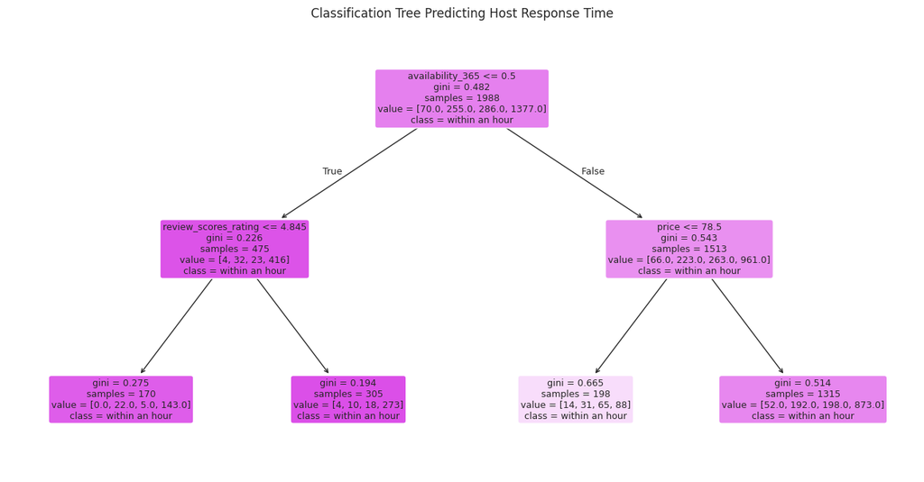

To predict host response time, I constructed a classification tree using numeric listing characteristics that plausibly relate to host engagement and professionalism, including price, number of beds, review scores rating, annual availability, and price per bed. Several model specifications were explored with different levels of tree depth and minimum leaf sizes to balance interpretability and predictive performance. Because host response time is a categorical outcome with notable class imbalance, I used an 80/20 train-test split with stratification and relied on cross-validation to select an appropriate tree size that would generalize well without overfitting.

## **Part 3: Transformer**

```
# Create 4 price bins
zurich["price_quartile"] = pd.qcut(
    zurich["price"],
    q=4,
    labels=["low", "mid_low", "mid_high", "high"]
)

zurich["price_quartile"].value_counts()
```

| price_quartile | count |
| --- | --- |
| mid_low | 623 |
| low | 622 |
| mid_high | 622 |
| high | 619 |

```
text_cols = ["description", "host_about", "amenities"]

zurich["text"] = (
    zurich[text_cols]
    .fillna("")
    .agg(" ".join, axis=1)
)
```

```
text_cols = ["description", "host_about", "amenities"]

zurich["text"] = (
    zurich[text_cols]
    .fillna("")
    .agg(" ".join, axis=1)
)
from sklearn.model_selection import train_test_split

X_train, X_test, y_train, y_test = train_test_split(
    zurich["text"],
    zurich["price_quartile"],
    test_size=0.2,
    random_state=42,
    stratify=zurich["price_quartile"]
)
```

```
from transformers import pipeline

classifier = pipeline(
    "zero-shot-classification",
    model="facebook/bart-large-mnli"
)
```

[output not shown]

```
labels = ["low", "mid_low", "mid_high", "high"]

sample_text = X_test.iloc[0]
true_label = y_test.iloc[0]

result = classifier(sample_text, labels)

print("True label:", true_label)
print("Predicted:", result["labels"][0])
```

```
True label: mid_low
Predicted: high
```

```
labels = ["low", "mid_low", "mid_high", "high"]

fictional_listing = """
Spacious two-bedroom apartment near central Zurich.
High-speed WiFi, full kitchen, washer and dryer included.
Professional host with very fast response times and excellent reviews.
"""

result = classifier(fictional_listing, labels)

print("Predicted price quartile:", result["labels"][0])
```

```
Predicted price quartile: high
```

The fictional listing was classified as high price, which is consistent with its central location, extensive amenities, and fast host response time.

For the third classification task, I used a pretrained transformer model to classify Airbnb listings in Zurich into four price quartiles based on textual information. The response variable, price_quartile, was created by dividing the nightly price into four equally sized categories: low, mid_low, mid_high, and high. As predictors, I combined three descriptive text fields—listing description, host information, and amenities—into a single text feature for each observation. Rather than training a transformer from scratch, I used a pretrained language model to leverage its ability to understand semantic patterns related to location, amenities, and listing quality reflected in the text.

# **Clustering**

```
zurich['price_per_bed'] = zurich['price'] / zurich['beds']
zurich['price_per_bed'] = zurich['price_per_bed'].replace([np.inf, -np.inf], np.nan).fillna(zurich['price_per_bed'].median())
```

```
features = ["price", "beds", "review_scores_rating",
            "minimum_nights", "availability_365", "price_per_bed"]
X_cluster = zurich[features].copy()
```

```
from sklearn.preprocessing import StandardScaler

scaler = StandardScaler()
X_scaled = scaler.fit_transform(X_cluster)
```

```
from sklearn.cluster import KMeans
from sklearn.metrics import silhouette_score
import matplotlib.pyplot as plt

scores = []
K_range = range(2, 11)

for k in K_range:
    km = KMeans(n_clusters=k, random_state=42)
    km.fit(X_scaled)
    scores.append(silhouette_score(X_scaled, km.labels_))

plt.plot(K_range, scores, marker="o")
plt.xlabel("Number of clusters (k)")
plt.ylabel("Silhouette Score")
plt.title("Silhouette Score by K")
plt.show()
```

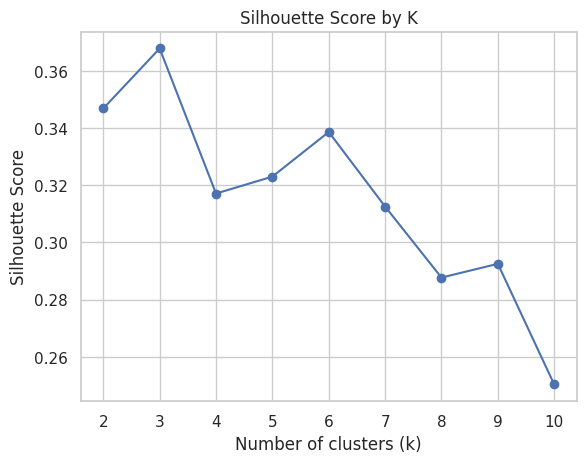

```
inertia = []
for k in K_range:
    kmeans = KMeans(n_clusters=k, random_state=42)
    kmeans.fit(X_scaled)
    inertia.append(kmeans.inertia_)

plt.figure(figsize=(8,5))
plt.plot(K_range, inertia, marker="o")
plt.xlabel("Number of clusters (K)")
plt.ylabel("Inertia (SSE)")
plt.title("Elbow Method: Determining K Value")
plt.grid(True, alpha=0.3)
plt.show()
```

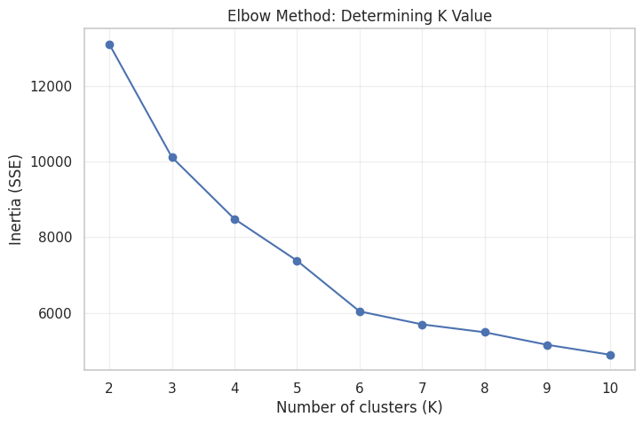

```
k = 6
kmeans = KMeans(n_clusters=k, random_state=42)
zurich["cluster"] = kmeans.fit_predict(X_scaled)
```

```
cluster_profile = (
    zurich.groupby("cluster")[
        ["price", "beds", "review_scores_rating",
         "minimum_nights", "availability_365", "price_per_bed"]
    ].mean().round(2)
)
print(cluster_profile)
zurich["cluster"].value_counts().sort_index()
```

```
          price  beds  review_scores_rating  minimum_nights  availability_365  \
cluster
0        138.16  1.41                  4.82           33.55            168.46
1        232.98  4.16                  4.77            3.32             97.27
2        549.03  1.74                  4.76            2.10            217.61
3        120.59  1.26                  4.81            4.22             38.89
4        155.15  1.31                  4.74            3.57            290.78
5        176.40  2.00                  0.69           12.67            160.67

         price_per_bed
cluster
0               103.89
1                61.30
2               365.47
3               100.67
4               126.20
5               114.27
```

| cluster | count |
| --- | --- |
| 0 | 239 |
| 1 | 207 |
| 2 | 179 |
| 3 | 1193 |
| 4 | 653 |
| 5 | 15 |

K-means clustering identified six distinct Airbnb market segments in Zurich. Cluster 0 represents extended-stay budget rooms, with low nightly rates but very high minimum night requirements. These listings appear to serve long-term visitors such as students or temporary workers. Cluster 3, the largest group, includes popular low-cost private rooms located centrally with strong review scores and limited availability — indicating high demand among short-stay budget travelers.

Cluster 1 contains premium multi-bedroom apartments with high overall prices but low cost per bed, making them suitable for families and business groups staying near central attractions. Cluster 2 reflects luxury boutique studios with very high nightly rates and strong ratings, often in desirable high-amenity neighborhoods, though their high availability suggests niche demand. Cluster 4 includes mid-range listings with weaker booking performance, which may be priced slightly above demand or located farther from high-traffic tourist zones. Finally, Cluster 5 captures a very small set of low-rated outlier listings — likely either problematic properties or new listings without review histories.

To build the clustering model, we selected features that represent key economic and consumer-experience drivers of Airbnb listing performance: price, beds (accommodation capacity), price per bed, review scores (guest satisfaction), minimum nights (booking flexibility), and availability over the past year (demand indicator). These variables together capture affordability, listing type, competitiveness, and guest appeal.

```
import seaborn as sns
plt.figure(figsize=(10, 6))
sns.scatterplot(
    data=zurich,
    x="review_scores_rating",
    y="price",
    hue="cluster",
    palette="viridis",
    alpha=0.7
)
plt.title("K-means Clusters: Price vs Rating")
plt.xlabel("Review Scores Rating")
plt.ylabel("Price")
plt.show()
```

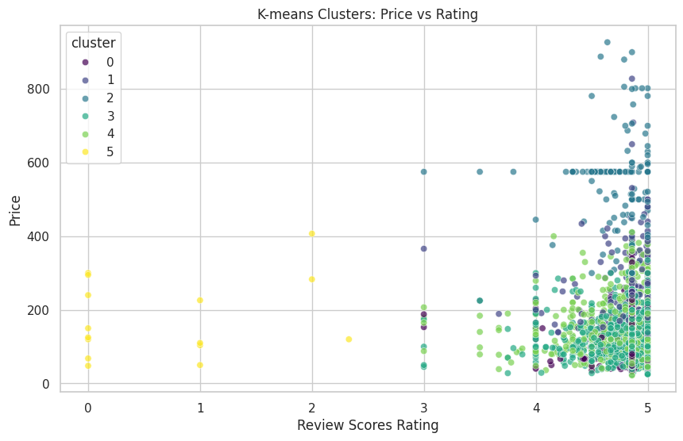

This scatterplot shows how the six K-means clusters differ in nightly price and guest review rating. Cluster 2 represents the luxury market, with the highest prices and strong ratings. Clusters 0, 3, and 4 form the core market — well-rated properties at lower to mid-range prices. Cluster 5 stands out as a small group of low-rated, inconsistently priced listings that may indicate quality issues. Overall, the visualization reveals clear price-tier segmentation among Zurich rentals

[output not shown]

```
import seaborn as sns
import matplotlib.pyplot as plt

sns.set_theme(style="whitegrid")

plt.rcParams.update({'font.size': 12})

plt.figure(figsize=(10, 10))

median_props = {
    'color': 'black',
    'linewidth': 2.5
}
flier_props = {
    'marker': 'o',
    'markerfacecolor': 'gray',
    'alpha': 0.6
}

sns.boxplot(
    data=zurich,
    x="cluster",
    y="price",
    palette="pastel",
    medianprops=median_props,
    flierprops=flier_props,
)

plt.title(
    "Price Distribution by Cluster",
    fontsize=18,
    fontweight='bold',
    pad=20
)
plt.xlabel("Cluster", fontsize=14, fontweight='semibold')
plt.ylabel("Nightly Price", fontsize=14, fontweight='semibold')

sns.despine(top=True, right=True)

plt.tight_layout()

plt.show()
```

```
/tmp/ipython-input-1831361444.py:20: FutureWarning:

Passing `palette` without assigning `hue` is deprecated and will be removed in v0.14.0. Assign the `x` variable to `hue` and set `legend=False` for the same effect.

  sns.boxplot(
```

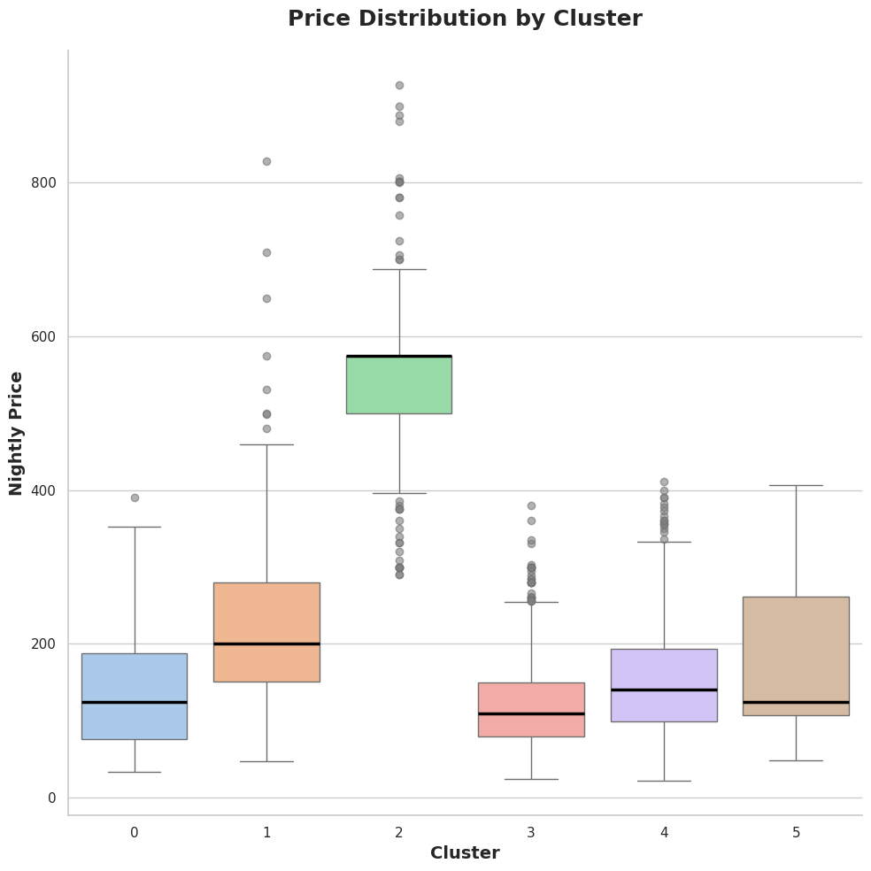

This boxplot highlights the differences in nightly pricing across the six K-means clusters. Cluster 2 stands out clearly as the premium segment, with the highest median price and many upper-end outliers. Clusters 0, 3, and 4 represent more affordable listings with tighter price ranges and fewer extreme values. Cluster 5 shows wide variability — some prices align with the mid-range, while others spike higher — suggesting a group with inconsistent listing quality or pricing strategy.

```
availability_means = zurich.groupby("cluster")["availability_365"].mean().reset_index()
sns.set_theme(style="whitegrid")

plt.rcParams.update({'font.size': 12})

plt.figure(figsize=(10, 7))

sns.barplot(
    data=availability_means,
    x="cluster",
    y="availability_365",
    palette="pastel",
)

plt.title(
    "Average Annual Availability by Cluster",
    fontsize=18,
    fontweight='bold',
    pad=20
)
plt.xlabel("Cluster", fontsize=14, fontweight='semibold')
plt.ylabel("Available Days per Year", fontsize=14, fontweight='semibold')

sns.despine(top=True, right=True)

plt.tight_layout()

plt.show()
```

```
/tmp/ipython-input-1619180662.py:8: FutureWarning:

Passing `palette` without assigning `hue` is deprecated and will be removed in v0.14.0. Assign the `x` variable to `hue` and set `legend=False` for the same effect.

  sns.barplot(
```

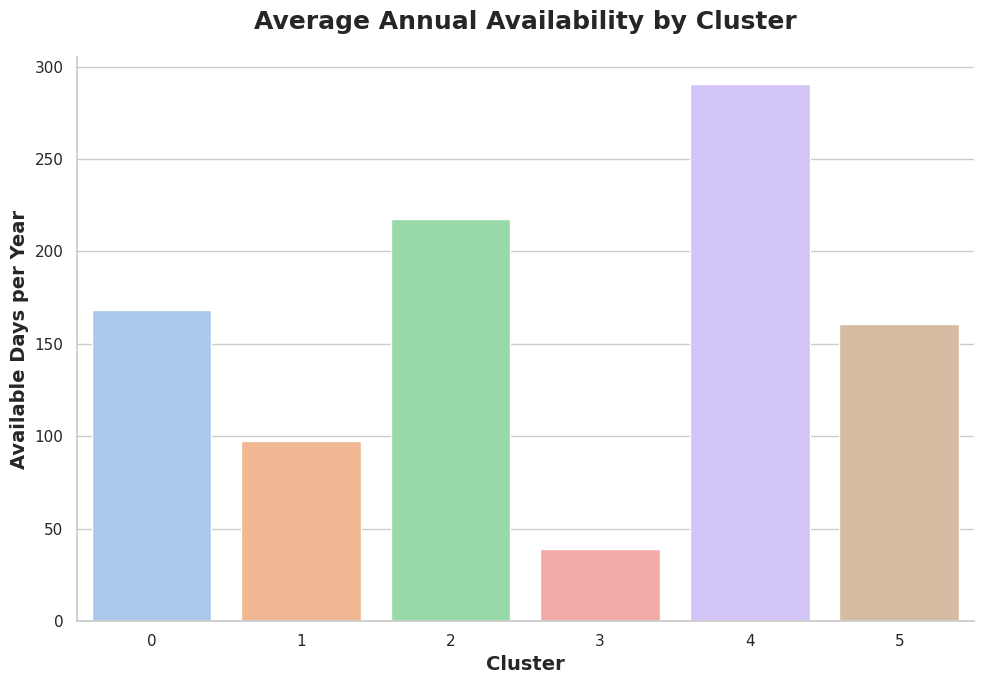

[output not shown]

This bar chart compares the average annual availability across clusters, revealing distinct hosting strategies. Cluster 4 has the highest availability, suggesting full-time rental units that operate like dedicated vacation properties. In contrast, Cluster 3 has the lowest availability, consistent with part-time listings likely managed by hosts who still occupy the property. Clusters 0, 1, 2, and 5 fall in the mid-range, indicating a mix of consistent tourist-focused rentals and more occasional hosting.

## Conclusions

This assignment provided a hands-on opportunity to apply the full data mining process, from initial data exploration through analysis and interpretation of results. The project required careful preparation of the dataset, including cleaning, transforming, and selecting relevant variables, which highlighted how crucial preprocessing is to producing meaningful and reliable outcomes. Working through these steps reinforced the importance of understanding the data context before applying any analytical techniques, rather than treating data mining as a purely mechanical task.

Throughout the analysis phase, various data mining and exploratory techniques were used to uncover patterns, relationships, and trends within the dataset. Interpreting these results required both technical reasoning and domain awareness, as not every statistically significant finding necessarily translates to practical relevance. The iterative nature of the process—refining methods, validating results, and revisiting assumptions—demonstrated how data mining is both analytical and exploratory, blending quantitative rigor with critical thinking.

The findings from this project could be useful in real-world decision-making scenarios where large datasets are available but insights are not immediately obvious. By identifying patterns and relationships, organizations can better understand behaviors, outcomes, or risk factors that may not surface through traditional analysis alone. These insights can inform strategy development, operational improvements, or targeted interventions depending on the context of the data.

Several groups could benefit from the data mining performed in this project. Business analysts, marketing professionals, policy makers, and organizational leaders could use similar approaches to guide evidence-based decisions. Additionally, data scientists and researchers could leverage these methods to build predictive models or support further investigation. Overall, this project emphasized the practical value of data mining as a tool for transforming raw data into actionable knowledge while reinforcing the importance of thoughtful interpretation and ethical use of analytical results